# EDAV project - Building Permits

Andres

April 4, 2018

## Project Background

The Second Avenue Subway, a New York City Subway line that runs under Second Avenue on the East Side of Manhattan, has been proposed since 1920. The first phase of the line, consisting of three stations on the Upper East Side, started construction in 2007 and opened in 2017, ninety-seven years after the route was first proposed. Up until the 1960s, many distinct plans for the Second Avenue subway line were never carried out, though small segments were built in the 1970s. The complex reasons for these delays are why the line is sometimes called “the line that time forgot” (source: Wikipedia).

A brief summary of more important milestones is:

1919: original proposal.  
1942 - 1956: Parallel elevated lines along Second Avenue and Third Avenue were demolished  
1960: Increase in development on East Side, existing Lexington Avenue Line became overcrowded.  
1967: voters approved a Transportation Bond Issue, which provided over $600 million (worth $4,404,000,000 today) for New York City projects. The City secured a $25 million Urban Mass Transportation Act (UMTA) grant for initial construction.  
1972: Construction on the line finally began  
1975: Initial construction was halted because of the NY city’s fiscal crisis, tunnels sealed later.  
1999: MTA Study proposed new subway service from 63rd Street north up Second Avenue to 125th Street.  
2000: MTA Capital Program Review Board approved the MTA’s 2000-2004 Capital Program, which allocated $1.05 billion for the construction of the 2nd Avenue Line.  
2001: the Federal Transit Administration approved the start of preliminary engineering on a full-length 2nd Ave Line.  
2004: Approval of MTA’s environmental impact statement (FEIS) proposing a two-track line from 125th Street and Lexington Avenue in Harlem, down Second Avenue to Hanover Square in the Financial District to be build in 4 phases:  
- Phase 1 rerouted the Q service via the BMT 63rd Street Line and north along Second Avenue, to the Upper East Side at 96th Street. - Phase 2 will extend the rerouted Q train to 125th Street and Lexington Avenue.  
- Phase Three, will run from 125th Street to Houston Street.  
- Phase will extend service from Houston Street to Hanover Square in Lower Manhattan.

##### Phase 1 only:

2005: Voters passed a transportation bond issue on November 8, 2005, allowing for dedicated funding allocated for phase 1.  
2006: United States Department of Transportation (USDOT) agave $1.3 billion in federal funding for the phase 1, to be funded over a seven-year period. Preliminary engineering and a final tunnel design was completed.  
2007: Final Phase 1 construction started.  
2017: after several news about progress and delays, phase 1 finally opened on Jan 1st. This phase 1 consisting of the 96th Street, 86th Street, and 72nd Street stations and two miles (3.2 km) of tunnel, had a cost of $4.45 billion.

##### Phase 2 only:

2015: phase 2 was allocated $535 million in the MTA’s 2015-2019 Capital Plan for planning, design, environmental studies, and utility relocation.  
2016: In March, MTA began advertising Requests for Proposals (RFP) for three new contracts for phase 2. In April 2016, the MTA and the State of New York reached a deal to restore funding to Phase 2, with a total of $1.035 billion allocated. On May 24, 2017, the MTA Board increased funding for Phase 2 to $1.735 billion.  
2017: by August 2017, preliminary work on the line was underway, and the engineering firm AKRF was updating the environmental impact study for Phase 2.

##### Phases 3 and 4:

Phases 3 and 4 have no funding commitments yet.

The full length of the project and it’s phases and stations can be easily visualized in the following graph:

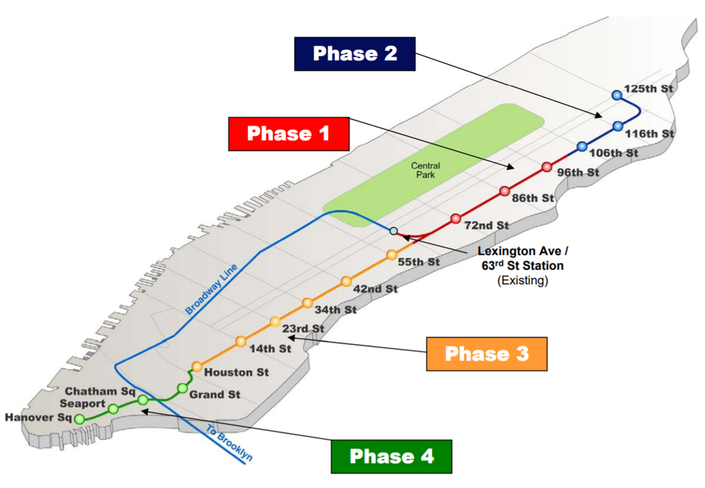

Source: http://www.apta.com/previousmc/multimodal/previous/2010/Presentations/Planning-for-the-Second-Avenue-Subway-From-Dream-to.pdf

## Analysis of Buliding Permits

One of the analysis we decided to perform to answer our question, was to see how the 2nd Ave line project has affected the construction of new buildings (and remodeling of existing ones) in the project’s area of influence (basically, phase 1 and 2, because phase 3 and 4 have no funding commitments yet).

We got the building permits dataset from “The NYC Open Data portal”: https://data.cityofnewyork.us/Housing-Development/DOB-Permit-Issuance/ipu4-2q9a

The dataset is a list of building permits filed for a particular day and associated data, from 1990 to date. It contains building permits for both new buildings and alterations / remodeling.

After downloading the original dataset (1.4GB, 3,341,659 observations), we read it, take a look at it and inspect variables/column names:

```r
library(tidyverse)
permits <- read.csv("DOB_Permit_Issuance.csv")
#head(permits)
colnames(permits) #print variables / column names
```

```
##  [1] "BOROUGH"                          "Bin.."
##  [3] "House.."                          "Street.Name"
##  [5] "Job.."                            "Job.doc..."
##  [7] "Job.Type"                         "Self_Cert"
##  [9] "Block"                            "Lot"
## [11] "Community.Board"                  "Zip.Code"
## [13] "Bldg.Type"                        "Residential"
## [15] "Special.District.1"               "Special.District.2"
## [17] "Work.Type"                        "Permit.Status"
## [19] "Filing.Status"                    "Permit.Type"
## [21] "Permit.Sequence.."                "Permit.Subtype"
## [23] "Oil.Gas"                          "Site.Fill"
## [25] "Filing.Date"                      "Issuance.Date"
## [27] "Expiration.Date"                  "Job.Start.Date"
## [29] "Permittee.s.First.Name"           "Permittee.s.Last.Name"
## [31] "Permittee.s.Business.Name"        "Permittee.s.Phone.."
## [33] "Permittee.s.License.Type"         "Permittee.s.License.."
## [35] "Act.as.Superintendent"            "Permittee.s.Other.Title"
## [37] "HIC.License"                      "Site.Safety.Mgr.s.First.Name"
## [39] "Site.Safety.Mgr.s.Last.Name"      "Site.Safety.Mgr.Business.Name"
## [41] "Superintendent.First...Last.Name" "Superintendent.Business.Name"
## [43] "Owner.s.Business.Type"            "Non.Profit"
## [45] "Owner.s.Business.Name"            "Owner.s.First.Name"
## [47] "Owner.s.Last.Name"                "Owner.s.House.."
## [49] "Owner.s.House.Street.Name"        "Ownerâ..s.House.City"
## [51] "Ownerâ..s.House.State"            "Ownerâ..s.House.Zip.Code"
## [53] "Owner.s.Phone.."                  "DOBRunDate"
## [55] "PERMIT_SI_NO"                     "LATITUDE"
## [57] "LONGITUDE"                        "COUNCIL_DISTRICT"
## [59] "CENSUS_TRACT"                     "NTA_NAME"
```

Then we filtered Manhattan Zip codes that are within the area of influence of phase1 and phase 2 of the project (10065, 10021, 10075, 10028, 10128, 10029, 10035) and selected relevant columns of our interest:

```r
#filter Manahattan zip codes of interest:
permits_upper_east <- filter(permits, BOROUGH=="MANHATTAN" & Zip.Code %in% c(10065, 10021, 10075, 10028, 10128, 10029, 10035))

#Select relevant columns of our interest:
permits_upper_east <- select(permits_upper_east, BOROUGH,House..,Street.Name,Job.Type,Block,Lot, Community.Board, Zip.Code,Bldg.Type,Residential,Work.Type,Permit.Type,Permit.Subtype,Filing.Date,Issuance.Date,Expiration.Date,Job.Start.Date,Owner.s.Business.Type,LATITUDE,LONGITUDE,COUNCIL_DISTRICT,NTA_NAME)
#head(permits_upper_east)
#write.table(permits_upper_east, file="DOB_Permit_Issuance-up_east_harlem.csv",sep=",",row.names=F)
```

### Analysis of Building Permits for Phase 1

Now we add a column called “Distance” and use the block number to record the approximate distance (in blocks) from each building filing a building permit, to the 2nd Ave Line or to an station entrance of the 2nd Ave Line.

For this purpose, we used the Block number column/variable and the official tax map for the City of New York, which graphically shows the the block number, street names and other information in the map. The link where we were able to access the online Digital Tax Map is: http://gis.nyc.gov/taxmap/map.html

Using that info, we were able to generate the following map, where we could manually place the pre-existing Lexington-Fourth Avenue Line (green line), the phase 1 of the 2nd Ave project (yellow line) and the stations entrances, to visually determine the block numbers that are near the phase 1 of the 2nd Ave line and their distance (in blocks) to the Line and to an station entrance:

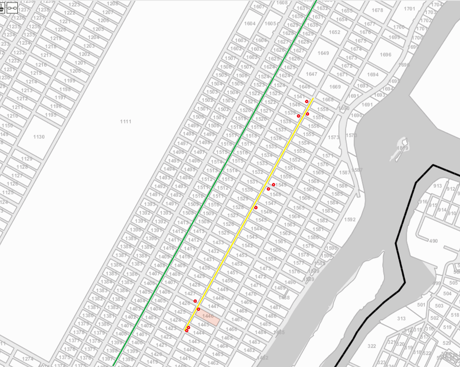

When determining the distances of the buildings to the 2nd Ave line, we differentiated between buildings to the left of the 2nd Ave Line and buildings to the right, because we suspected that the influence of the 2nd Ave Line may be greater for buildings to the right of the line than for buildings to the left, due to the proximity of the pre-existing Lexington-Fourth Avenue green Line right to the left of the 2nd Ave Line project.

Before starting with the analysis, we needed to convert dates columns/variables from Factor to Date format and Block number variable from Factor to numeric:

```r
permits_upper_east$Filing.Date = as.Date(permits_upper_east$Filing.Date, format = "%m/%d/%Y")
permits_upper_east$Issuance.Date = as.Date(permits_upper_east$Issuance.Date, format = "%m/%d/%Y")
permits_upper_east$Expiration.Date = as.Date(permits_upper_east$Expiration.Date, format = "%m/%d/%Y")
permits_upper_east$Job.Start.Date = as.Date(permits_upper_east$Job.Start.Date, format = "%m/%d/%Y")
permits_upper_east$Block = as.numeric(permits_upper_east$Block)
#head(permits_upper_east)
```

#### Buildings on the left side of the 2nd Ave Line - Phase 1

For blocks to the left of the 2nd Ave Line, as we can see in the map above, we can determine 3 different categories:

1. block numbers that are within 1 block to the left;
2. block numbers that are within 2-3 blocks to the left; and
3. block numbers that are within 4-5 blocks to the left; from the 2nd Ave Line

Using the block numbers for each of the 3 categories detailed above, we can add a column called “Distance” and use the block number to record the approximate distance (in blocks) from each building filing a building permit, to the left of 2nd Ave Line - phase 1:

```r
data_phase1 <- permits_upper_east %>%
  mutate(Distance = ifelse(Block %in% c(1424:1427, 1529:1532,1539:1541,1423,1428:1433,
                                        1525:1528,1533:1538,1646),
                                 '1 block left from 2nd Ave line',
                          ifelse(Block %in% c(1404:1407,1512:1515,1522:1524,1403,1408:1413,
                                              1508:1511,1516:1521,1624),
                                 '2-3 blocks left from 2nd Ave line',
                          ifelse(Block %in% c(1384:1387,1495:1498,1505:1507,1383,1388:1393,
                                              1491:1494,1499:1504,1602),
                                 '4-5 blocks left from 2nd Ave line',
                                 'other'))))
```

Now we can visualize and compare the variation of new and remodeling building permits over time, among the different categories detailed above.

For this purpose, we first summarize by Filing.Date year and Distance, then we scale the data and create an index to visualize variations over time with time series lines for recent years:

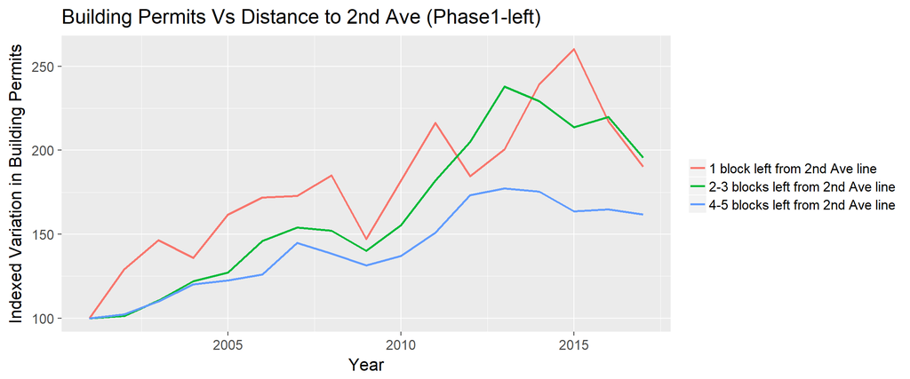

```r
#First, summarize by Filing.Date year and Distance:
library(lubridate) #dates library
data_phase1 <- data_phase1 %>%
  group_by(Filing.Year = year(Filing.Date), Distance) %>%
  summarise(Total = n()) %>%
  arrange(Filing.Year) #arranges from lowest to highest value

#Now, scale the data and create an index to visualize variations over time, then plot:
data_phase1 <- data_phase1 %>% group_by(Distance) %>%
  filter(Filing.Year >= 2001 & Filing.Year <= 2017) %>%
  filter(Distance != "other") %>%
  mutate(index = 100*Total/Total[1]) %>% ungroup()

#save results to be used for presentation purposes:
write.table(data_phase1,file="Permits_Distance-to-2nd-ave-line_phase1_left.csv",sep=",",row.names=F)

#Plot time series:
ggplot(data_phase1, aes(Filing.Year, index, color = Distance)) + geom_line(lwd = 1) +
    ggtitle("Building Permits Vs Distance to 2nd Ave (Phase1-left)") +
    labs (x = "Year", y = "Indexed Variation in Building Permits") +
    theme_grey(16) +
    theme(legend.title = element_blank())
```

**Conclusion:** From the graph above, it seems that to the left side of the 2nd Avenue Line - phase 1, the number of building permits filed is related to the distance in blocks from the 2nd Ave line project.

Since the phase 1 opened on January 1st, 2017; we see the decrease in building permit filings as an expected result, as one would expect that new/remodeled residential and business buildings are planned ahead and not after the finalization of the project. We can later try to verify if this theory is adequate when we analyze the effect of phase 2 of the project, which, as mentioned in the project background summary, is just in preliminary works stage.

#### Buildings on the right side of the 2nd Ave Line - Phase 1

For blocks to the right of the 2nd Ave Line, as we can see in the map above, there are just 3 blocks between the 2nd Ave Line and the East River, except for a small row of few blocks located four blocks from the line(at the north end), so we established 3 different categories as follows:

1. block numbers that are within 1 block to the right;
2. block numbers that are within 2 blocks to the right; and
3. block numbers that are within 3-4 blocks to the right; from the 2nd Ave Line

Using the block numbers for each of those 3 categories, we followed the same procedure performed to analyze buildings to the left, going back to the original data to add a column called “Distance” and use the block number to record the approximate distance (in blocks) from each building filing a building permit, to the right of 2nd Ave Line - phase 1:

```r
data_phase1 <- permits_upper_east %>%
  mutate(Distance = ifelse(Block %in% c(1444:1447,1546:1549,1556:1558,1443,1448:1453,
                                        1542:1545,1550:1555,1668),
                                 '1 block right from 2nd Ave Line',
                          ifelse(Block %in% c(1464:1467,1563:1566,1573,1463,1468:1473,
                                              1559:1562,1567:1571,1690),
                                 '2 blocks right from line',
                          ifelse(Block %in% c(1482:1484,1580:1583,1480,1485:1490,1576:1579,
                                              1584:1587,1590,1592,1589),
                                 '3-4 blocks right from 2nd Ave Line',
                                 'other'))))
```

Now we can visualize and compare the variation of building permits over time, among the different categories detailed above, by following the same procedure described previously:

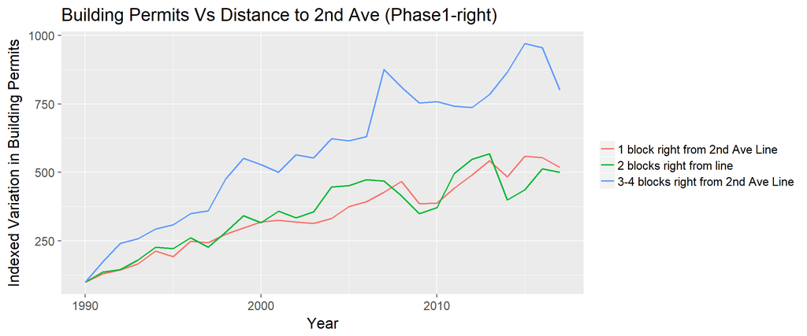

```r
#First, summarize by Filing.Date year and Distance:
library(lubridate) #dates library
data_phase1 <- data_phase1 %>%
  group_by(Filing.Year = year(Filing.Date), Distance) %>%
  summarise(Total = n()) %>%
  arrange(Filing.Year) #arranges from lowest to highest value

#Now, scale the data and create an index to visualize variations over time, then plot:
data_phase1 <- data_phase1 %>% group_by(Distance) %>%
  filter(Filing.Year >= 1990 & Filing.Year <= 2017) %>%
  filter(Distance != "other") %>%
  mutate(index = 100*Total/Total[1]) %>% ungroup()

#Plot time series:
ggplot(data_phase1, aes(Filing.Year, index, color = Distance)) + geom_line(lwd = 0.75) +
    ggtitle("Building Permits Vs Distance to 2nd Ave (Phase1-right)") +
    labs (x = "Year", y = "Indexed Variation in Building Permits") +
    theme_grey(16) +
    theme(legend.title = element_blank())
```

**Preliminary Conclusions:** Initially, we had plotted just recent years (similar to what we did for buildings on the left side of the line), but we noted that the category ‘3-4 blocks right from 2nd Ave line’ had higher increase in variation than other lines which was not an expected result.

However, after plotting from the initial year when data is available (1990) we could see that historically, that block of buildings have always had a higher increase in the number of building permits, which made us think it is due to the fact that this last category is right on the edge of the East River, which would attract a higher number of projects than the other categories, due to the water views.

To isolate that phenomenon, we could just remove the category ‘3-4 blocks right from line’ which would be the category affecting the results, but then we would need some more visual evidence to see if the project seems to affect the filing of building permits or not.

For that purpose, we further differentiated the category ‘1 block right from 2nd Ave Line’ into the following 2 categories:

1. buildings located within a 1 block radius from a 2nd Ave Line station entrance (right side)
2. all other buildings, within 1 block right from 2nd Ave Line

Similarly, we further differentiated the category ‘2 blocks right from 2nd Ave Line’ into the following 2 categories:

3. buildings located within 2 block radius from a 2nd Ave Line station entrance (right side)
4. all other buildings, within 2 blocks right from 2nd Ave Line

Using the block numbers for each of the 4 categories detailed above, we followed the same procedure described previously, adding a column called “Distance” to record the approximate distance (in blocks) to the right of the 2nd Ave Line project - phase 1 and its stations entrances:

```r
data_phase1 <- permits_upper_east %>%
  mutate(Distance = ifelse(Block %in% c(1444:1447,1546:1549,1556:1558),
                                  '1 block radius from station entrance (right side)',
                          ifelse(Block %in% c(1443,1448:1453,1542:1545,1550:1555,1668),
                                 'other, 1 block right from line',
                          ifelse(Block %in% c(1464:1467,1563:1566,1573),
                                  '2 block radius from station entrance (right side)',
                          ifelse(Block %in% c(1463,1468:1473,1559:1562,1567:1571,1690),
                                 'other, 2 blocks right from line',
                                 'other')))))
```

Now we can visualize and compare the variation of building permits over time, among the different categories detailed above, by following the same procedure described previously:

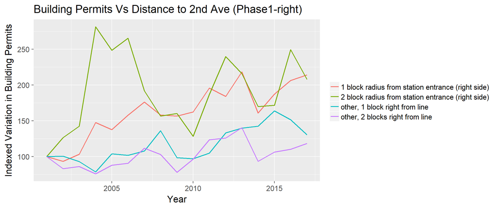

```r
#First, summarize by Filing.Date year and Distance:
library(lubridate) #dates library
data_phase1 <- data_phase1 %>%
  group_by(Filing.Year = year(Filing.Date), Distance) %>%
  summarise(Total = n()) %>%
  arrange(Filing.Year) #arranges from lowest to highest value

#Now, scale the data and create an index to visualize variations over time, then plot:
data_phase1 <- data_phase1 %>% group_by(Distance) %>%
  filter(Filing.Year >= 2001 & Filing.Year <= 2017) %>%
  filter(Distance != "other") %>%
  mutate(index = 100*Total/Total[1]) %>% ungroup()

#save results to be used for presentation purposes:
write.table(data_phase1,file="Permits_Distance-to-2nd-ave-line_phase1_right.csv",sep=",",row.names=F)

#Plot time series:
ggplot(data_phase1, aes(Filing.Year, index, color = Distance)) + geom_line(lwd = 0.75) +
    ggtitle("Building Permits Vs Distance to 2nd Ave (Phase1-right)") +
    labs (x = "Year", y = "Indexed Variation in Building Permits") +
    theme_grey(16) +
    theme(legend.title = element_blank())
```

**Conclusion:** As we can clearly appreciate in the graph above, it seems that the variation in building permits filed is indeed related to the 2nd Ave Line project.

### Analysis of Building Permits for Phase 2

For phase 2 of the project, we followed the same procedure, using approximate station entrances according to phase 2 project plan:

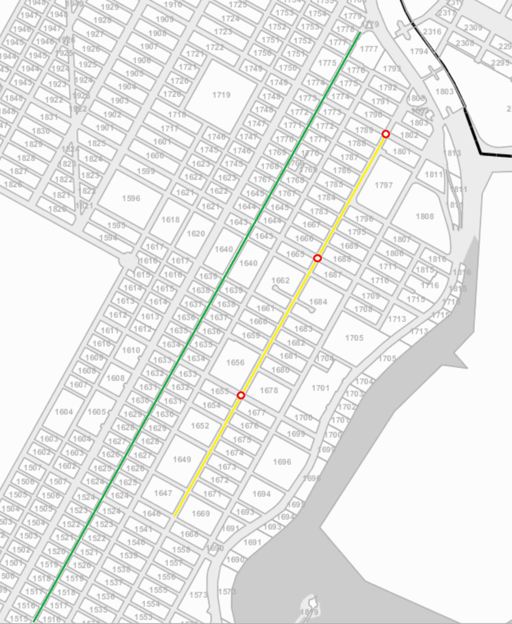

Here, we initially followed the same methodology described in phase 1, but found the same phenomenon of blocks located right next to the East River, having historically higher increase in the number of building permits (since 1990 when data is available), which seems to confirm our theory that this is because they attract a higher number of projects than the other categories, due to the water views.

To isolate that phenomenon and considering that the block numbering system doesn’t allow us to differentiate buildings in the third row of blocks from buildings in the second row of blocks, we focused our analysis in buildings located one block left and one block right from phase 2 of the 2nd Ave Line project.

Using the map above, we established the following 4 different categories:

2 categories for buildings located within 1 block to the left of the line:

1. buildings located within a 2 blocks radius from a 2nd Ave phase 2 station entrance (left side);
2. all other buildings, within 1 block left from 2nd Ave Line;

and other 2 categories for buildings located within 1 block to the right of the line:

3. buildings located within a 2 blocks radius from a 2nd Ave phase 2 station entrance (right side);
4. all other buildings, within 1 block right from 2nd Ave phase 2 Line

Using the block numbers for each of the 4 categories detailed above, we added a column called “Distance” to record the approximate distance (in blocks) from each building filing a building permit from the phase 2 of the 2nd Ave Line project and its projected station entrances:

```r
data_phase2 <- permits_upper_east %>%
  mutate(Distance = ifelse(Block %in% c(1654:1656, 1665:1667, 1788:1791),
                           '2 blocks from stations -phase 2- (1 block left from line)',
                          ifelse(Block %in% c(1647:1652,1659:1662,1783:1787),
                                 'other, 1 block left from phase 2 line',
                          ifelse(Block %in% c(1676:1678, 1687:1689, 1801:1803),
                           '2 blocks from stations -phase 2- (1 block right from line)',
                          ifelse(Block %in% c(1669:1675,1680:1684,1795:1797),
                                 'other, 1 block right from phase 2 line',
                                 'other')))))
```

Now we can visualize and compare the variation of building permits during recent years, among the different categories detailed above, by following the same procedure described previously:

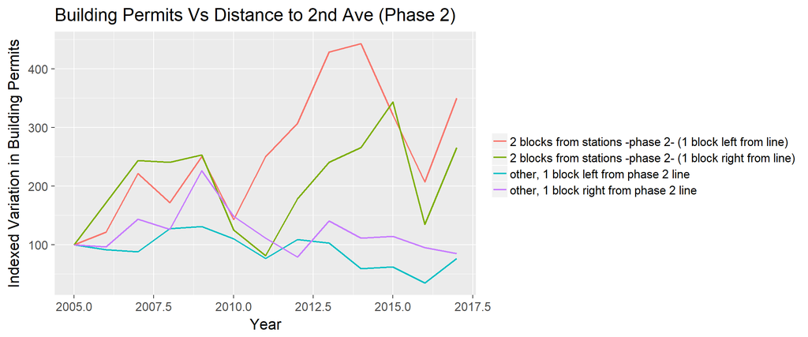

```r
#First, summarize by Filing.Date year and Distance:
library(lubridate) #dates library
data_phase2 <- data_phase2 %>%
  group_by(Filing.Year = year(Filing.Date), Distance) %>%
  summarise(Total = n()) %>%
  arrange(Filing.Year) #arranges from lowest to highest value

#Now, scale the data and create an index to visualize variations over time, then plot:
data_phase2 <- data_phase2 %>% group_by(Distance) %>%
  filter(Filing.Year >= 2005 & Filing.Year <= 2017) %>%
  filter(Distance != "other") %>%
  mutate(index = 100*Total/Total[1]) %>% ungroup()

#save results to be used for presentation purposes:
write.table(data_phase1,file="Permits_Distance-to-2nd-ave-line_phase2.csv",sep=",",row.names=F)

#Plot time series:
ggplot(data_phase2, aes(Filing.Year, index, color = Distance)) + geom_line(lwd = 0.75) +
    ggtitle("Building Permits Vs Distance to 2nd Ave (Phase 2)") +
    labs (x = "Year", y = "Indexed Variation in Building Permits") +
    theme_grey(16) +
    theme(legend.title = element_blank())
```

**Conclusions:** Analyzing the graphic results obtained, it seems that within one block of distance to the phase 2 of the 2 Ave Line project, the number of building permits filed is related to the distance in blocks from the 2nd Ave line project, with buildings within a 2 blocks radius from a planned station entrance, showing considerably higher increase in filed building permits (both left and right from the 2nd Ave Line).

Contrary to our findings in phase 1 which opened on January 1st, 2017, where we found a decrease in building permit filings during 2017 (which we considered reasonable as one would expect that new/remodeled residential and business buildings are planned ahead and not after the finalization of the project); here we can see that the building permit filings actually increased during 2017, when preliminary works for this phase started, and they have higher increases starting in 2011-2013, after some recovery from 2008 financial crisis, when news were coming out about the so long waited 2nd Ave Line finally becoming a reality and tunneling machines successfully making its way through ground, building the tunnels for phase 1.

**Additional work performed:** After our analysis, we tried several plots to try to find out if there was any different relationship by plotting buildings owned by individuals Vs buildings owned by corporations, but we didn’t find any interesting result.

As final step, we decided to present the results from our EDA in a map, so we summarized and saved our data, using the variables LATITUDE and LONGITUDE, instead of using the Distance variable that we created for EDA purposes:

```r
#First, save frequency (one row per observation):
data_geo <- permits_upper_east %>%
  mutate(Filing.Year = year(Filing.Date))%>%
  select(Filing.Year, LATITUDE, LONGITUDE) #%>%
  #arrange(Filing.Year) #arranges from lowest to highest value

#save results to be used for presentation purposes:
write.table(data_geo,file="Building_Permits_Lat-Long-all-obvs.csv",sep=",",row.names=F)

#Now, save frecuency count:
library(lubridate) #dates library
data_geo2 <- permits_upper_east %>%
  group_by(Filing.Year = year(Filing.Date), LATITUDE, LONGITUDE) %>%
  summarise(Total = n()) %>%
  arrange(Filing.Year) #arranges from lowest to highest value

#save results to be used for presentation purposes:
write.table(data_geo2,file="Building_Permits_Lat-Long-Counted.csv",sep=",",row.names=F)

#Finally, save variation index:
data_geo_index <- data_geo2 %>% group_by(LATITUDE, LONGITUDE) %>%
  mutate(index = 100*Total/Total[1]) %>% ungroup() %>%
  select(Filing.Year, index, LATITUDE, LONGITUDE)

#save results to be used for presentation purposes:
write.table(data_geo_index,file="Building_Permits_Lat-Long-index.csv",sep=",",row.names=F)
```